# Assignment 2

Deconstruct, Reconstruct Web Report

Jason Thomas (s3907634)

### Assessment declaration checklist

Please carefully read the statements below and check each box if you agree with the declaration. If you do not check all boxes, your assignment will not be marked. If you make a false declaration on any of these points, you may be investigated for academic misconduct. Students found to have breached academic integrity may receive official warnings and/or serious academic penalties. Please read more about academic integrity [here](https://www.rmit.edu.au/students/student-essentials/assessment-and-exams/academic-integrity). If you are unsure about any of these points or feel your assessment might breach academic integrity, please contact your course coordinator for support. It is important that you DO NOT submit any assessment until you can complete the declaration truthfully.

**By checking the boxes below, I declare the following:**

- I have not impersonated, or allowed myself to be impersonated by, any person for the purposes of this assessment
- This assessment is my original work and no part of it has been copied from any other source except where due acknowledgement is made. Due acknowledgement means the following:
  - The source is correctly referenced in a reference list
  - The work has been paraphrased or directly quoted
  - A citation to the original work’s reference has been included where the copied work appears in the assessment.
- No part of this assessment has been written for me by any other person except where such collaboration has been authorised by the lecturer/teacher concerned.
- I have not used generative “AI” tools for the purposes of this assessment.
- Where this work is being submitted for individual assessment, I declare that it is my original work and that no part has been contributed by, produced by or in conjunction with another student.
- I give permission for my assessment response to be reproduced, communicated, compared and archived for the purposes of detecting plagiarism.
- I give permission for a copy of my assessment to be retained by the university for review and comparison, including review by external examiners.

**I understand that:**

- Plagiarism is the presentation of the work, idea or creation of another person or machine as though it is your own. It is a form of cheating and is a very serious academic offence that may lead to exclusion from the University. Plagiarised material can be drawn from, and presented in, written, graphic and visual form, including electronic data and oral presentations. Plagiarism occurs when the origin of the material used is not appropriately cited.
- Plagiarism includes the act of assisting or allowing another person to plagiarise or to copy my work.

**I agree and acknowledge that:**

- I have read and understood the Declaration and Statement of Authorship above.
- If I do not agree to the Declaration and Statement of Authorship in this context and all boxes are not checked, the assessment outcome is not valid for assessment purposes and will not be included in my final result for this course.

## Deconstruct

### Original

The original data visualisation selected for the assignment was as follows:

[figure not shown]

*Source: Newsweek, “Most Religious Countries in the World.*

### Objective and Audience

The objective and audience of the original data visualisation chosen can be summarised as follows:

**Objective**

To show which countries are most religious. More specifically, by placing the data in a map, the objective was probably to represent the geographic distribution of religiosity worldwide.

**Audience**

Newsweek is a general news website, so the audience is a general and non-technical audience.

### Critique

The visualisation chosen had the following three main issues:

- The visualisation uses a palette of colours from across the colour spectrum, which would be appropriate for categorical data. However, the variable of interest is continuous and placed in levels, meaning that these levels have order. A sequential colour scale would be more appropriate.
- The mapping from levels in the data to colours is confusing: “No Data” has a colour and is in the palette’s middle. The palette also does not observe any sensible order in relation to the levels of the variable of interest, which is evident from looking at the legend.
- A map is not the right choice for this data. Many large landmasses have no data, meaning there are large gaps in the data visualisation. Also, it is somewhat interesting to see that some areas of Earth are more religious than others, but it would be more interesting to see if religiosity correlates with some other variable other than location on Earth.

## Reconstruct

This visualisation would be more interesting if religiosity was plotted against some other variable, like some measure of poverty.

Using a scatter plot to see a correlation would address the issue of “No Data” in the original map, since scatter plots do not alert the audience to missing data. But a note on the visualisation should explain that some countries do not have available data. To draw the reader’s attention to the correlation, each chart can have a “line of best fit”. Most readers in a general audience will know what this means.

One issue with the visualisation that was not previously mentioned is it does not link to the data source, but only names Pew Research Centre. The most likely source is a report by Pew in June of 2024. The data in that report is displayed in a horizontal bar chart with vertical gridlines at 20%, 40%, 60% and 80%, which match the levels of the Newsweek map’s data.

Of particular interest would be this question: does religiosity correlate with poverty? To achieve this, we will combine that data with another dataset. A faceted data visualisation will allow for consideration of many levels of poverty severity.

### Code

The following code was used to fix the issues identified in the original. Note that a small amount of data cleaning and prep was done in MS Excel.

```r
poverty = read.csv("poverty-explorer.csv")

poverty[, "Share.10.to.20.a.day"] <- poverty[, "Share.below..20.a.day"] -
  poverty[, "Share.below..10.a.day"]
poverty[, "Share.20.to.30.a.day"] <- poverty[, "Share.below..30.a.day"] -
  poverty[, "Share.below..20.a.day"]
poverty[, "Share.30.to.40.a.day"] <- poverty[, "Share.below..40.a.day"] -
  poverty[, "Share.below..30.a.day"]

poverty2008To2012 = poverty[poverty$Year %in% c('2008','2009','2010','2011','2012'), c("Country", "Year", "Share.below..10.a.day", "Share.10.to.20.a.day", "Share.20.to.30.a.day", "Share.30.to.40.a.day")]

# Collect data from 2010, but take the closes year if 2010 is not available.
order <- c('2010', '2011', '2009', '2012', '2008')
library(dplyr)
povertyClosestYear <- poverty2008To2012 %>%
  arrange(factor(Year, levels = order)) %>%
  distinct(Country, .keep_all = TRUE)

religion2010 = read.csv("ReligionPerCountry_2010.csv")
religion2010$Unaffiliated = gsub('[<%]', '', religion2010$Unaffiliated)
religion2010$Unaffiliated = as.numeric(religion2010$Unaffiliated)
religion2010$Religious = 100 - religion2010$Unaffiliated
religion2010 = religion2010[,c("Country","Religious")]

mergedData = merge(povertyClosestYear, religion2010, by = "Country")
mergedData <- mergedData[,c("Share.below..10.a.day",
                            "Share.10.to.20.a.day",
                            "Share.20.to.30.a.day",
                            "Share.30.to.40.a.day",
                            "Religious")]

# Make data long for ggplot
library(tidyr)
mergedDataLong <- mergedData %>%
  gather(IncomeBracket, ShareInBracket, -Religious)

variable_names <- list(
  "Share.below..10.a.day" = "$0 to $10 per day" ,
  "Share.10.to.20.a.day" = "$10 to $20 per day",
  "Share.20.to.30.a.day" = "$20 to $30 per day",
  "Share.30.to.40.a.day" = "$30 to $40 per day"
)
variable_labeller <- function(variable,value){
  return(variable_names[value])
}
```

### Reconstruction

The following plot fixes the main issues in the original.

The code here is non-trivial, and is echoed in case it is of interest.

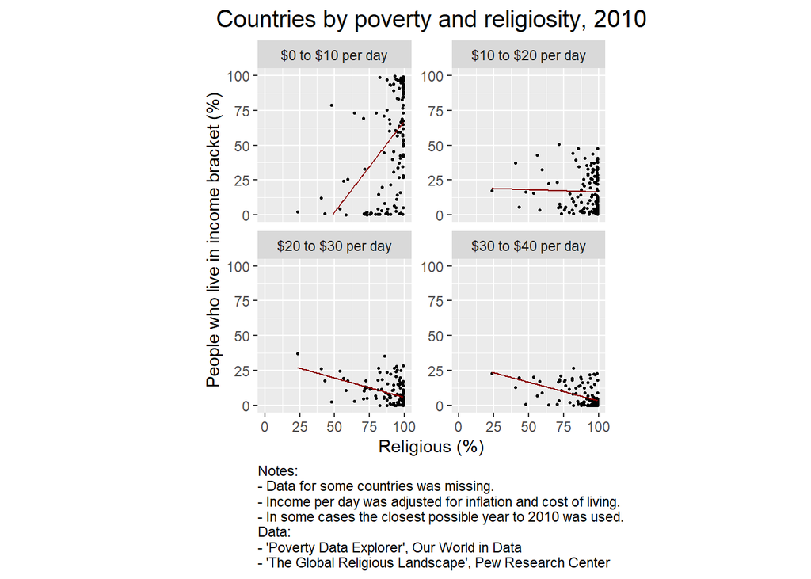

```r
library("ggplot2")

ggplot(mergedDataLong, aes(x=Religious, y=ShareInBracket)) +
  geom_point(size = 0.5) +
  theme(aspect.ratio = 1,
        plot.title = element_text(hjust = 0.5,size = 15),
        plot.caption = element_text(hjust = 0)) +
  labs(x= "Religious (%)",
       y="People who live in income bracket (%)",
       title= "Countries by poverty and religiosity, 2010",
       caption = "Notes:\n- Data for some countries was missing.\n- Income per day was adjusted for inflation and cost of living.\n- In some cases the closest possible year to 2010 was used.\nData:\n- 'Poverty Data Explorer', Our World in Data\n- 'The Global Religious Landscape', Pew Research Center") +
  ylim(0,100) +
  xlim(0,100) +
  geom_smooth(method=lm, se=FALSE, linetype="solid", color="darkred", linewidth = 0.5) +
  facet_wrap(~factor(IncomeBracket, levels=c("Share.below..10.a.day",
                                             "Share.10.to.20.a.day",
                                             "Share.20.to.30.a.day",
                                             "Share.30.to.40.a.day")),
             scales="free_y", ncol=2, labeller= variable_labeller)
```

## References

The reference to the original data visualisation, the data sources used for the reconstruction are as follows:

- https://www.newsweek.com/map-shows-most-religious-countries-2024-1942346
- likely data source https://www.pewresearch.org/religion/2024/06/17/religion-and-spirituality-in-east-asian-societies/
- new data source https://assets.pewresearch.org/wp-content/uploads/sites/11/2014/01/global-religion-full.pdf
- poverty data https://ourworldindata.org/explorers/poverty-explorer